# Natural Language Processing Lab 2

- Show All Code
- Hide All Code

Author

Lonny Chen

Published

September 9, 2026

# 1 Objectives

Welcome to the second Natural Language Processing lab, where we dive into the initial preprocessing stage of the NLP pipeline.

Today’s objectives are:

1. 🧽 Practice using string operations and **regular expressions** as tools for initial data cleaning of text data.
2. 📋 Compare how different choices in **rules-based** tokenization and normalization affect results of the downstream task of sentiment analysis.
3. 🔢 Compare rules-based with **data-driven** tokenization and how it affects results of the downstream task.

## 1.1 Packages

Required packages are listed in this lab’s requirements.txt. We will be focusing on three essential NLP packages today:

1. `re`: the Python built-in module for **regular expressions**.
   - [Python module](https://docs.python.org/3/library/re.html)
   - Cheat sheets: [CoderPad](https://coderpad.io/regular-expression-cheat-sheet/), [DataQuest](https://www.dataquest.io/cheat-sheet/regular-expressions-cheat-sheet/)
   - [Everything you need to know and then some!](https://www.regular-expressions.info/)
2. `spacy`: the current NLP standard for **rules-based** language processing pipeline.
   - [Linguistic Features](https://spacy.io/usage/linguistic-features)
   - [Processing Pipeline](https://spacy.io/usage/processing-pipelines)
3. `tokenizers`: from the HuggingFace ecosystem providing the **data-driven** tokenizers that enable the latest DL/LLMs.
   - [Subword Tokenization](https://huggingface.co/learn/llm-course/chapter2/4#subword-tokenization)
   - Training Algorithms: [BPE](https://huggingface.co/learn/llm-course/chapter6/5), [WordPiece](https://huggingface.co/learn/llm-course/chapter6/6), [Unigram](https://huggingface.co/learn/llm-course/chapter6/7)

Honourable mentions:

1. `nltk`: an older Natural Language Toolkit (NLTK) that provides finer-grained configuration of some preprocessing operations.
   - We use their [Snowball stemmer](https://www.nltk.org/api/nltk.stem.snowball.html) because spaCy doesn’t provide one!
2. `sklearn`: we use scikit-learn for all of the vectorization and sentiment analysis classification
   - [CountVectorizer](https://scikit-learn.org/stable/modules/generated/sklearn.feature_extraction.text.CountVectorizer.html) actually wraps a lot of tokenization operations. Here, we use it to tokenize N-grams.

**Import packages**

```python
# Data packages
import pandas as pd
pd.set_option('display.max_colwidth', None) #default: 50 chars
pd.set_option('display.max_columns', None) #default: 20 columns
import numpy as np

# NLP packages
import re
from sklearn.feature_extraction.text import CountVectorizer
import spacy
from nltk.stem.snowball import SnowballStemmer
from tokenizers import Tokenizer, pre_tokenizers
from tokenizers.models import BPE, WordPiece, Unigram
from tokenizers.trainers import BpeTrainer, WordPieceTrainer, UnigramTrainer

# Classification libraries
from sklearn.model_selection import train_test_split, GridSearchCV
from sklearn.linear_model import LogisticRegression
from sklearn.metrics import make_scorer, f1_score, classification_report
```

# 2 Data Cleaning Activity

Even before tokenization, we typically, especially for messy “in the wild” text data, need to do some data cleaning which can entail:

- Filtering in/out texts (including/excluding)
- Extracting information from texts
- Transforming texts: standardize, restructure, remove

We practice **transforming** and then **extracting** information using the (completely!) fictional data below.

## 2.1 Text Input

A Hertie RA made a mistake on a Hertie alumni donation form and asked for information in open-ended format! It’s up to us to clean and then structure the data as best we can. The form question is:

> Please write your name, email address, program, year of graduation, donor list hashtag (if any), and your alumni donation amount in Euros.

**Load data cleaning dataset**

```python
dfc = pd.read_csv('nlp_lab2_data_cleaning.csv')
dfc.head()
```

## 2.2 Cleaning with String Replace

Let’s just look at the first issue:

1. Correct all fuzzy spellings of `'#HertieLove'`

With simple **string operations**, we can only replace exact strings but that becomes unfeasible if the dataset were much larger.

```python
dfc['text2'] = dfc['text'].apply(lambda x: x.replace('HertieLoveeeee', 'HertieLove'))
dfc['text2'] = dfc['text2'].apply(lambda x: x.replace('HertieLuv', 'HertieLove'))
dfc['text2'] = dfc['text2'].apply(lambda x: x.replace('HertieLuuuv', 'HertieLove'))
dfc[['text2']].head()
```

## 2.3 Cleaning with Regex

This is where the utility of **regular expressions** (regex) comes in! We use regex to identify fuzzy or variable patterns and then substitute or extract text based on our needs.

A good process to follow for verifying regex’s (it usually takes a few to many rounds!):

1. Create your regex pattern
2. Test on a representative string(s) -> **Great tool for this is [regex101](https://regex101.com/)**
3. Apply to an entire list of strings (here, in a Pandas series)
4. Check for correctness

**NoteWhy we use raw strings**

If we didn’t use r”…” raw strings, we would have to escape the backslash, i.e., `'\\d'` instead of just `'\d'` and that would make regex’s even more difficult to read!

```python
text = '#HertieLoveeeee'
pattern = r"#HertieLove" # MODIFY to find the pattern variations to replace
repl = '#HertieLove'
re.sub(pattern, repl, text)
```

**MODIFY: Apply to all strings in dataset**

```python
dfc['text2'] = dfc['text'].apply(lambda x: re.sub(r"#HertieLove", '#HertieLove', x)) #1. MODIFY for '#HertieLove'
dfc[['text2']].head()
```

## 2.4 More Cleaning with Regex

Let’s continue our cleaning list with regex:

1. Correct all fuzzy spellings of `'#HertieLove'` **DONE**
2. Standardize all versions of MDS to `'MDS'`.
3. Correct invalid starting years to `'ERROR'` (only for 202x)
4. Correct accidentally repeated names (leave only one)

**MODIFY: Apply text corrections using regex**

```python
dfc['text2'] = dfc['text'].apply(lambda x: re.sub(r"#HertieLove", '#HertieLove', x)) #1. MODIFY for '#HertieLove'
dfc['text2'] = dfc['text2'].apply(lambda x: re.sub(r"MDS", 'MDS', x)) #2. MODIFY for 'MDS'
dfc['text2'] = dfc['text2'].apply(lambda x: re.sub(r"ERROR", r"ERROR", x)) #3. MODIFY for 'ERROR' years (202x)
#dfc['text2'] = dfc['text2'].apply(lambda x: re.sub(r"(.*)\1", r"\1", x)) #4. MODIFY for repeated names
dfc[['text2']].head()
```

## 2.5 Extracting with Regex

Extracting information using regex works similarly except the found string needs to be saved to a data structure.

1. Full name (assuming consecutive capitalized title case)
2. Email address
3. Donation amount

Here, we collect lists of information and then arrange them in a Pandas `DataFrame`.

**MODIFY: Extract text strings using regex**

```python
full_names = dfc['text2'].apply(lambda x: re.search(r"\w", x).group()) #1. MODIFY for full names
emails = dfc['text2'].apply(lambda x: re.search(r"\w", x).group()) #2. MODIFY for email addresses
donation_amounts = dfc['text2'].apply(lambda x: re.search(r"\d", x).group(1)) #3. MODIFY for donation amounts (capture group 1)
pd.DataFrame({'Full Name': full_names, 'Email': emails, 'Donation': donation_amounts})
```

# 3 Research Question

We now move onto a full pipeline research question. Our mini-research question for this lab is:

> **How do preprocessing choices in tokenization and normalization affect a downstream task such as sentiment analysis?**

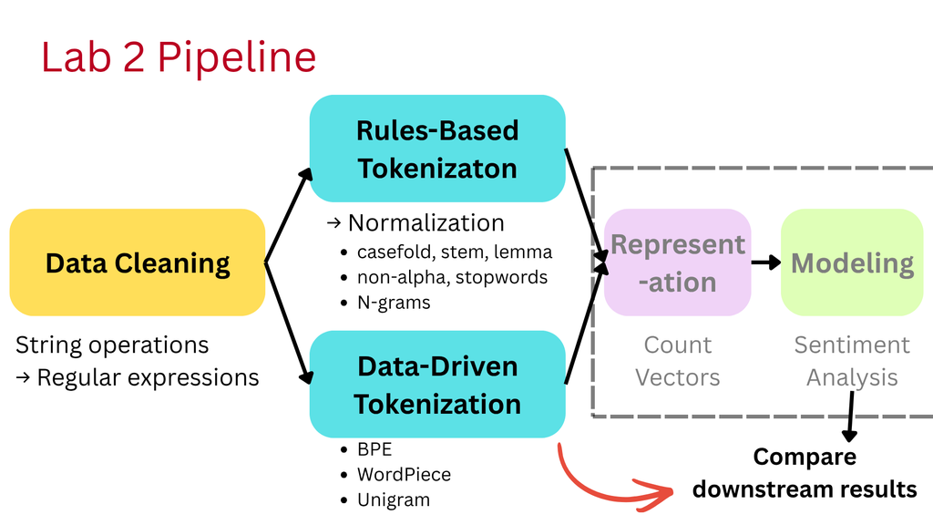

pipeline

# 4 Text Input

We’ll be using a Google Maps restaurant reviews dataset from Türkiye 🇹🇷 found on [Kaggle](https://www.kaggle.com/datasets/denizbilginn/google-maps-restaurant-reviews). It has been modified for positive and negative sentiment classes (originally from a 5-point scale, neutral “3” dropped).

**Load modified restaurant reviews dataset**

```python
df = pd.read_csv('reviews_sentiment.csv')
print(f'The shape of this dataset is {df.shape}')
df.sample(2)
```

# 5 Data Cleaning

Luckily, these reviews are fairly clean. The one issue is that the way the Turkish currency of the **lira** is used is not consistent. Let’s standardize `'tl'`, `'TL'`, and `'liras'` all to `'lira'`.

**MODIFY: Standardize ‘lira’ using regex**

```python
texts = [
    "46 liras for 6 meatballs; 30 minutes or more waiting time.",
    'It is very interesting that french fries are 114 TL.',
    'We ate cafe Inn pizza. It was 70 tl.',
    'In general; I was satisfied; since the hamburger is a little small;'] # Don't change the 'tl' in 'little'!

pattern = r"lira" # MODIFY for finding alternative variations for 'lira'
repl = 'lira'
for t in texts:
    print(re.sub(pattern, repl, t))
```

**CHECK: Apply to the dataset and check**

```python
df1 = df.copy()
df1['text'] = df1['text'].apply(lambda x: re.sub(pattern, repl, x))
df1[df1['text'].str.contains(r"\d+[Tt][Ll]")]
```

**MODIFY: An edge case to fix?**

```python
texts = ['We paid 240tl for the table you see in the photo;',
         'Prices too high Turkish coffee 42.5TL Salty cookies weak.']

pattern = r"(\d)" # MODIFY for alternative variations for 'lira'
repl = r"\1 lira"
for t in texts:
    print(re.sub(pattern, repl, t))
```

**CHECK: Apply to the dataset and check**

```python
df2 = df1.copy()
df2['text'] = df2['text'].apply(lambda x: re.sub(pattern, repl, x))
df2[df2['text'].str.contains(r"\d+[Tt][Ll]")]
```

# 6 Rules-Based Tokenization

After data cleaning, tokenization is the step of splitting up each text into smaller parts of text, called **tokens**. These tokens are then represented numerically and then this representation is used to enable the downstream NLP task(s). There are generally two branches of tokenization:

1. **Rules-based:** We make choices based on rules of each language and the needs of the research or application domain.
2. **Data-driven:** The tokenization is driven by statistical algorithms.

## 6.1 Rules-Based: Tokenize on Whitespace

We can use Python’s built-in string `split()` method to simply split each text into tokens by whitespace. This can be our baseline for our downstream task. As for each our tokenization step, we first see how the tokenization looks on one example text, and then apply it to the dataset.

```python
text = "The San Francisco-based restaurant doesn't charge $10."
tokens = text.split()
tokens
```

```python
dft = df2.copy() #for tokenization
dft['tokens'] = dft['text'].str.split() #entire dataset
dft[['text', 'tokens']].sample(2)
```

### 6.1.1 View Count Vector

We use the “count vector” representation provided by scikit-learn’s `'CountVectorizer'` method.

**Define function for count vectorizer**

```python
def count_vectorize_to_df(s_tokens, s_text):
    '''Vectorize each text into a count vector of token frequencies, and output as DataFrame.'''
    vectorizer = CountVectorizer(
        analyzer=lambda tokens: tokens, # disable CountVectorizer's tokenization
    )
    X_bow = vectorizer.fit_transform(s_tokens)
    print(f'The vocabulary size is {len(vectorizer.vocabulary_)} tokens')
    return pd.DataFrame(X_bow.toarray(), index=s_text, columns=vectorizer.get_feature_names_out())
```

```python
df_bow = count_vectorize_to_df(dft['tokens'], dft['text'])
df_bow.sample(1)
```

### 6.1.2 Evaluate Sentiment Classifier

**Define function for sentiment analysis classifier**

```python
def sentiment_analysis_pipeline(X, y, min_df=1, max_df=1.0, max_features=None, ngram_range=(1,1)):
    '''docstring'''

    # For uni-gram vs. bi-grams
    if ngram_range == (1,1):
        analyzer = (lambda tokens: tokens)
    else:
        analyzer = 'word'
        X = X.apply(' ' .join) #bi-grams need full strings

    # Train/test split
    X_train, X_test, y_train, y_test = train_test_split(
        X, y,
        test_size=0.2, #80/20 split
        random_state=42,
        stratify=y
    )
    # Vector representation (train/test separately!)
    vectorizer = CountVectorizer(
        analyzer=analyzer,
        min_df=min_df, max_df=max_df, max_features=max_features, ngram_range=ngram_range # allow user setting
    )
    X_train_bow = vectorizer.fit_transform(X_train)
    X_test_bow = vectorizer.transform(X_test)
    print(f'The vocabulary size is {len(vectorizer.vocabulary_)} tokens')

    # Find best parameter on training data
    f1_scorer = make_scorer(f1_score, pos_label='positive')
    grid = GridSearchCV(
        LogisticRegression(max_iter=1000),
        param_grid={'C': [0.01, 0.1, 1, 10, 100]},
        cv=5,
        scoring=f1_scorer
    )
    grid.fit(X_train_bow, y_train)
    best_model = grid.best_estimator_

    # Evaluate on held-out test data
    y_pred = best_model.predict(X_test_bow)
    print(classification_report(y_test, y_pred))
```

```python
sentiment_analysis_pipeline(dft['tokens'], dft['sentiment'])
```

## 6.2 Rules-Based: Tokenize with spaCy

We now turn to more sophisticated ways to tokenize based on linguistic properties provided by the spaCy package.

```python
#spacy.cli.download('en_core_web_sm') #Download (once) if you haven't yet # sm(all) is faster but no embeddings
nlp = spacy.load('en_core_web_sm')
text = "The San Francisco-based restaurant doesn't charge $10."
doc = nlp(text)
print([token.text for token in doc])
```

**NoteDisable parts of the spaCy pipeline**

For large datasets where processing speed matters, you can disable parts of the spaCy pipeline which you don’t need. But do so careful as some components depend on each other, for example, the Lemmatizer depends on some of the earlier components.

```python
docs_as_tokens = list(nlp.pipe(dft['text'])) # entire dataset
dft['tokens_spacy'] = [
    [token.text for token in doc] # SAME baseline tokenized text, no normalization
    for doc in docs_as_tokens] # per-document
dft[['text', 'tokens_spacy']].sample(2)
```

**Vectorize: view vocabulary size and count vector**

```python
df_bow = count_vectorize_to_df(dft['tokens_spacy'], dft['text'])
df_bow.sample(1)
```

```python
sentiment_analysis_pipeline(dft['tokens_spacy'], dft['sentiment'])
```

## 6.3 Rules-Based: Normalization

After tokenizing, there are numerous normalization choices to make including:

- **Case folding:** using `token.lower_` provided by spaCy’s tokenizer
- **Stemming:** using NLTK’s `SnowballStemmer` (“stems” may not result in real words)
- **Lemmatization:** using `token.lemma` provided by spaCy’s lemmatizer (standardize to base meaning “lemma”)
- **Remove non-alphabetical** using `token.is_alpha` provided by spaCy’s tokenizer
- **Remove stopwords** using `token.is_stop` provided by spaCy’s tokenizer and English stop word list
  - Stopword lists for different languages are available on spaCy’s GitHub:
    - [English](https://github.com/explosion/spaCy/blob/master/spacy/lang/en/stop_words.py)
    - [German](https://github.com/explosion/spaCy/blob/master/spacy/lang/de/stop_words.py)
    - [Spanish](https://github.com/explosion/spaCy/blob/master/spacy/lang/es/stop_words.py)
    - [Hindi](https://github.com/explosion/spaCy/blob/master/spacy/lang/hi/stop_words.py)

```python
text = "The San Francisco-based restaurant doesn't charge $10."
doc = nlp(text) # spaCy
my_stemmer = SnowballStemmer('english') # NLTK

# Normalization CHOICES
print([token.lower_ for token in doc]) # Case folding
print([my_stemmer.stem(token.text) for token in doc]) # Stemming
print([token.lemma_ for token in doc]) # Lemmaitzation -> case-fold with .lower()
print([token.text for token in doc if token.is_alpha]) # Remove non-alphabetical
print([token.text for token in doc if not token.is_stop]) # Remove stopwords
```

### 6.3.1 Normalizaiton Choices

We apply the normalization choices to the entire dataset using a **nested list comprehension**. Try various options and combinations and see how the various classification metrics change. Some examples are provided.

```python
docs_as_tokens = list(nlp.pipe(dft['text'])) # entire dataset
dft['tokens_spacy'] = [

    # MODIFY HERE
    [token.text for token in doc] # no normalization)
    #[token.lemma_.lower() for token in doc] # combine lemma + lower
    #[token.lower for token in doc if token.is_alpha and not token.is_stop] # combine case-folding, removal of non-alpha/stopwords

    for doc in docs_as_tokens] # per-document

# Vectorize (vocab count), run classifier
sentiment_analysis_pipeline(dft['tokens_spacy'], dft['sentiment'])
```

## 6.4 Rules-Based: N-grams

N-grams combine N neighboring words into one token using scikit-learn’s `CountVectorizer`. It may help to limit the number of features using `max_features` as the number of N-gram tokens can become very large.

```python
sentiment_analysis_pipeline(
    dft['tokens_spacy'], dft['sentiment'],
    max_features=None, # MODIFY HERE: maximum vocabulary size (default: None)
    ngram_range=(1,1) # MODIFY HERE: min_n, max_n (default: (1,1))
)
```

# 7 Data-Driven Tokenization

We not turn to data-driven tokenization algorithms provided by HuggingFace’s `tokenizer` library.

## 7.1 Data-Driven: Byte-Pair Encoding

The Byte-Pair Encoding (BPE) algorithm is described [here](https://huggingface.co/learn/llm-course/chapter6/5) by HuggingFace. It uses the merging criterion of “the pair that occurs most often” and its token vocabulary is built from the bottom up.

```python
vocab_size = 1000 # MODIFY HERE

tokenizer_bpe = Tokenizer(BPE(unk_token='[UNK]'))
tokenizer_bpe.pre_tokenizer = pre_tokenizers.Whitespace()
trainer_bpe = BpeTrainer(vocab_size=vocab_size, special_tokens=['[UNK]'])
tokenizer_bpe.train_from_iterator(dft['text'], trainer_bpe) # train from corpus

def bpe_tokenize(text):
    return tokenizer_bpe.encode(text).tokens

text = "The San Francisco-based restaurant doesn't charge $10."
print(bpe_tokenize(text))
```

**TipDISCUSS**

Why is `'$'` an unknown token when the trained tokenizer tokenizes the example text?

**BPE: Tokenize dataset and evaluate classifier**

```python
dft['tokens_bpe'] = dft['text'].apply(bpe_tokenize) # entire dataset
sentiment_analysis_pipeline(dft['tokens_bpe'], dft['sentiment']) # Vectorize, classify
```

## 7.2 Data-Driven: WordPiece

The WordPiece algorithm is described [here](https://huggingface.co/learn/llm-course/chapter6/6) by HuggingFace. It uses the merging criterion of “the pair that most improves corpus likelihood” and its token vocabulary is built from the bottom up.

```python
vocab_size = 1000 # MODIFY HERE

tokenizer_wp = Tokenizer(WordPiece(unk_token='[UNK]'))
tokenizer_wp.pre_tokenizer = pre_tokenizers.Whitespace()
trainer_wp = WordPieceTrainer(vocab_size=vocab_size, special_tokens=['[UNK]'])
tokenizer_wp.train_from_iterator(dft['text'], trainer_wp) # train from corpus

def wp_tokenize(text):
    return tokenizer_wp.encode(text).tokens

text = "The San Francisco-based restaurant doesn't charge $10."
print(wp_tokenize(text))
```

**WordPiece: Tokenize dataset and evaluate classifier**

```python
dft['tokens_wp'] = dft['text'].apply(wp_tokenize)
sentiment_analysis_pipeline(dft['tokens_wp'], dft['sentiment'])
```

## 7.3 Data-Driven: Unigram

```python
vocab_size = 1000 # MODIFY HERE

tokenizer_uni = Tokenizer(Unigram())
tokenizer_uni.pre_tokenizer = pre_tokenizers.Whitespace()
trainer_uni = UnigramTrainer(vocab_size=vocab_size, unk_token='[UNK]', special_tokens=['[UNK]'])
tokenizer_uni.train_from_iterator(dft['text'], trainer_uni) # train from corpus

def uni_tokenize(text):
    return tokenizer_uni.encode(text).tokens

text = "The San Francisco-based restaurant doesn't charge $10."
print(uni_tokenize(text))
```

**Unigram: Tokenize dataset and evaluate classifier**

```python
dft['tokens_uni'] = dft['text'].apply(uni_tokenize)
sentiment_analysis_pipeline(dft['tokens_uni'], dft['sentiment'])
```

# 8 Evaluation

What conclusions can we draw about the various tokenization (rules/words vs. data/subwords) and normalization choices and their affect on this dataset’s sentiment analysis classification? Can they be generalized across datasets?